# Math 189/289 Lab 2

Jiaqi Guo & L

# Get and Set Working Directory

R has a working directory. This should be the main location to store external data files, as well as other code files.

```r
getwd()
```

```
[1] "/Users/Lee/Documents/UCSD/Courses/MATH 189/Labs"
```

One can also set the working directory to a desired location.

```r
setwd("/Users/Lee/Documents/UCSD/Courses/MATH 189/Labs") # desired directory as argument
getwd()
```

```
[1] "/Users/Lee/Documents/UCSD/Courses/MATH 189/Labs"
```

# Read in Data

Please make sure the external data file is in the working directory. There are multiple functions to read in external data into R, depending on the file format. After reading in the external file, data is usually stored in an R dataframe. One can also peak into the data by using `head()` function.

```r
data <- read.table("../Case Study 1/babies.txt", header=TRUE)
head(data)
```

|  | bwt | gestation | parity | age | height | weight | smoke |
| --- | --- | --- | --- | --- | --- | --- | --- |
| 1 | 120 | 284 | 0 | 27 | 62 | 100 | 0 |
| 2 | 113 | 282 | 0 | 33 | 64 | 135 | 0 |
| 3 | 128 | 279 | 0 | 28 | 64 | 115 | 1 |
| 4 | 123 | 999 | 0 | 36 | 69 | 190 | 0 |
| 5 | 108 | 282 | 0 | 23 | 67 | 125 | 1 |
| 6 | 136 | 286 | 0 | 25 | 62 | 93 | 0 |

# Summary of Data

One of the most efficient way to learn about the data is through `summary()` function, which contains min, 1st quartile, median, mean, 3rd quartile, and max of each column.

```r
summary(data)
```

```
      bwt          gestation         parity            age            height          weight        smoke
 Min.   : 55.0   Min.   :148.0   Min.   :0.0000   Min.   :15.00   Min.   :53.00   Min.   : 87   Min.   :0.0000
 1st Qu.:108.8   1st Qu.:272.0   1st Qu.:0.0000   1st Qu.:23.00   1st Qu.:62.00   1st Qu.:115   1st Qu.:0.0000
 Median :120.0   Median :280.0   Median :0.0000   Median :26.00   Median :64.00   Median :126   Median :0.0000
 Mean   :119.6   Mean   :286.9   Mean   :0.2549   Mean   :27.37   Mean   :64.67   Mean   :154   Mean   :0.4644
 3rd Qu.:131.0   3rd Qu.:288.0   3rd Qu.:1.0000   3rd Qu.:31.00   3rd Qu.:66.00   3rd Qu.:140   3rd Qu.:1.0000
 Max.   :176.0   Max.   :999.0   Max.   :1.0000   Max.   :99.00   Max.   :99.00   Max.   :999   Max.   :9.0000
```

# Mean, standard deviations, and quantiles of data

```r
mean(data$bwt)
```

```
[1] 119.5769
```

```r
sd(data$bwt)
```

```
[1] 18.23645
```

```r
quantile(data$bwt)
```

```
    0%    25%    50%    75%   100%
 55.00 108.75 120.00 131.00 176.00
```

### Quantiles

$\alpha$-quantile of a random variable $X$, denoted as $q_\alpha$, is define as $P(X \leq q_\alpha) = \alpha$. This will require knowledge of the distribution $X$ follows. The quantile for normal distribution, for example, can be found using `qnorm()` function. This number for standard normal distribution is also known as the $z$-score. The sample quantile is available from the function `quantile()`.

```r
qnorm(0.95)
```

```
[1] 1.644854
```

```r
quantile(data$bwt, 0.17)
```

```
17%
103
```

# Acessing Data

To access a column of the data, one can simply use `[...]` to select. A dataframe work similar as a matrix; however, it does offer additional flexibility and information in handling data. For example, one can select a column of a dataframe by column number or column name. Both returns the same entry values. However, selecting by column number returns the raw data, whereas selecting by column name returns a dataframe with column information. Quotation marks are necessary, if column name is used for selection.

```r
data[,7] # This will return a vector
```

[output not shown]

```r
data['smoke'] # return a dataframe
```

| smoke |
| --- |
| 0 |
| 0 |
| 1 |
| 0 |
| 1 |
| 0 |
| 0 |
| 0 |
| 0 |
| 1 |

[output cut: 990 more lines]

Also, `$` may be used to access a certain data field, which is equivalent to selecting by column number.

```r
data$smoke # return a vector
```

[output not shown]

Acessing certain rows of the data is usually straightforward using the row numbers.

```r
data[100,]
```

|  | bwt | gestation | parity | age | height | weight | smoke |
| --- | --- | --- | --- | --- | --- | --- | --- |
| 100 | 105 | 254 | 0 | 29 | 64 | 137 | 0 |

In addition, we introduce selecting rows based on a certain condition here, which is useful in application. To see which rows contain observations of smokers, we use `which()` function, which returns indices of observations from smokers.

```r
smoker.ind <- which(data['smoke'] == 1)
smoker.ind
```

```
  [1]    3    5   10   12   13   14   17   18   20   22   26   28   30   38   39   43   45   46   50   52   57   63   64   65   66   68   69
 [28]   73   75   77   80   84   86   89   90   95   97  101  104  105  111  113  115  117  120  126  128  132  133  135  139  141  145  148
 [55]  149  155  157  158  166  168  169  172  176  178  182  186  190  191  193  194  195  198  203  207  208  210  211  213  220  222  224
 [82]  228  229  230  231  233  236  241  242  243  244  245  251  254  260  262  263  266  269  274  275  277  280  281  283  284  285  287
[109]  292  293  294  296  298  299  302  307  309  310  311  312  314  315  316  317  318  327  328  330  333  336  337  340  341  342  343
[136]  347  348  349  351  353  355  359  360  362  364  369  374  375  376  379  382  387  388  389  392  395  396  398  407  416  418  419
[163]  421  424  428  429  432  434  435  438  443  444  448  449  454  456  458  460  463  464  465  466  467  469  472  474  475  476  477
[190]  478  480  481  483  484  485  488  489  491  492  499  501  502  503  504  505  509  510  513  515  516  517  518  520  523  527  529
[217]  532  533  536  543  546  548  549  554  558  562  563  568  569  570  571  573  575  576  582  583  586  590  592  594  598  602  603
[244]  604  608  609  610  612  613  619  620  622  625  632  635  636  638  639  641  644  648  649  654  656  657  660  661  663  665  667
[271]  668  669  671  673  676  678  683  689  691  694  695  697  698  699  701  707  712  713  715  716  717  718  727  735  736  738  742
[298]  745  751  754  756  757  760  761  762  763  765  771  775  781  785  786  791  793  794  799  800  802  803  805  807  809  812  813
[325]  817  819  821  829  831  832  833  834  846  848  849  852  853  855  860  861  868  869  878  879  883  884  886  894  897  903  904
[352]  906  908  909  913  914  919  924  926  928  929  931  932  934  935  936  938  940  941  947  950  953  954  956  958  962  966  967
[379]  968  970  977  980  982  985  986  988  989  991  995 1000 1003 1005 1006 1007 1008 1010 1011 1013 1016 1018 1021 1023 1028 1041 1044
[406] 1047 1051 1052 1056 1058 1059 1060 1062 1063 1065 1066 1070 1072 1073 1087 1089 1090 1091 1102 1103 1106 1107 1108 1110 1119 1124 1128
[433] 1131 1133 1134 1136 1137 1142 1144 1146 1148 1149 1150 1151 1153 1155 1160 1162 1163 1165 1169 1170 1171 1175 1176 1177 1180 1183 1187
[460] 1188 1190 1192 1195 1196 1197 1198 1199 1201 1204 1207 1208 1209 1211 1212 1216 1219 1222 1223 1224 1225 1226 1227 1228 1234
```

To use the indices, we can pass in the vector of indices. Also, the `setdiff()` function is useful in set difference operations.

```r
data.smoker <- data[smoker.ind,]
data.smoker
```

|  | bwt | gestation | parity | age | height | weight | smoke |
| --- | --- | --- | --- | --- | --- | --- | --- |
| 3 | 128 | 279 | 0 | 28 | 64 | 115 | 1 |
| 5 | 108 | 282 | 0 | 23 | 67 | 125 | 1 |
| 10 | 143 | 299 | 0 | 30 | 66 | 136 | 1 |
| 12 | 144 | 282 | 0 | 32 | 64 | 124 | 1 |
| 13 | 141 | 279 | 0 | 23 | 63 | 128 | 1 |
| 14 | 110 | 281 | 0 | 36 | 61 | 99 | 1 |
| 17 | 92 | 255 | 0 | 25 | 65 | 125 | 1 |
| 18 | 115 | 261 | 0 | 33 | 60 | 125 | 1 |
| 20 | 119 | 288 | 0 | 43 | 66 | 142 | 1 |
| 22 | 115 | 274 | 0 | 27 | 67 | 175 | 1 |

[output cut: 474 more lines]

```r
data.nonsmoker <- data[-smoker.ind,]
data.nonsmoker
```

|  | bwt | gestation | parity | age | height | weight | smoke |
| --- | --- | --- | --- | --- | --- | --- | --- |
| 1 | 120 | 284 | 0 | 27 | 62 | 100 | 0 |
| 2 | 113 | 282 | 0 | 33 | 64 | 135 | 0 |
| 4 | 123 | 999 | 0 | 36 | 69 | 190 | 0 |
| 6 | 136 | 286 | 0 | 25 | 62 | 93 | 0 |
| 7 | 138 | 244 | 0 | 33 | 62 | 178 | 0 |
| 8 | 132 | 245 | 0 | 23 | 65 | 140 | 0 |
| 9 | 120 | 289 | 0 | 25 | 62 | 125 | 0 |
| 11 | 140 | 351 | 0 | 27 | 68 | 120 | 0 |
| 15 | 114 | 273 | 0 | 30 | 63 | 154 | 0 |
| 16 | 115 | 285 | 0 | 38 | 63 | 130 | 0 |

[output cut: 742 more lines]

```r
# Or we can use setdiff()
nonsmoker.ind <- setdiff(rownames(data), smoker.ind)'
data.nonsmoker <- data[nonsmoker.ind,]
data.nonsmoker
```

[output not shown]

# Graphs from Data

In many cases, graphs may be more straightforward than numeric values. We first introduce historgrams. Histrograms plot frequencies versus the values. Below is an application of the function `hist()`, a base function provided in R.

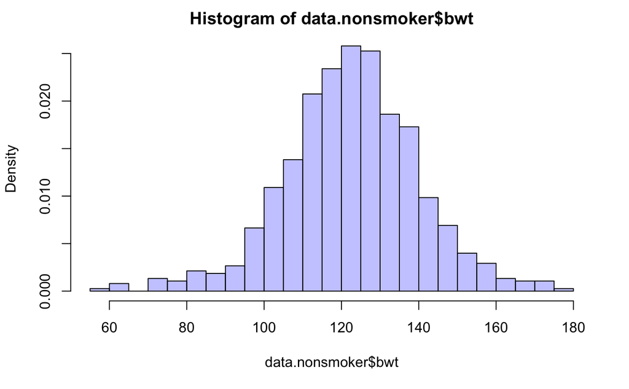

In addition to histograms, boxplots provide visualization when comparing a column of multiple categories. The argument ‘formula’ of boxplot works much like an equation. It tells R the variable relation between two variables. This will come up again when we talk about regressions.

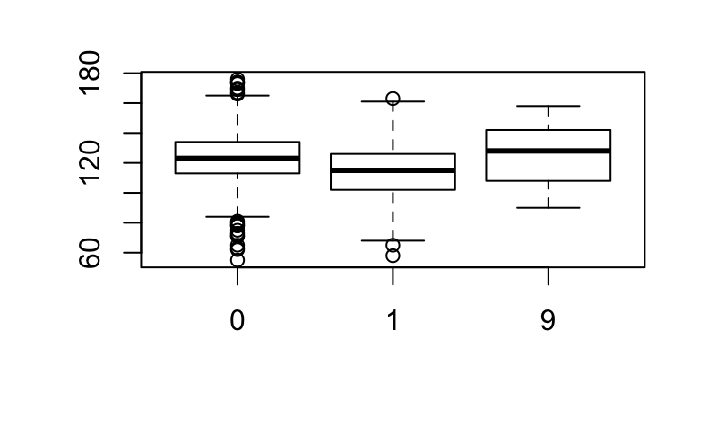

```r
boxplot(bwt~smoke, data)
```

Note that from the plots and summary statistics, one can often detect irregular values in data, which requires additional inspection and cleaning.

# Check for Normality

## 1. Histogram

```r
curve(data.smoker$bwt)
```

```
Error in curve(data.smoker$bwt) :
  'expr' must be a function, or a call or an expression containing 'x'
```

## 2.Skewness and Kurtosis

```r
# install.packages('moments')
library(moments)
```

```
Error in library(moments) : there is no package called ‘moments’
```

## 3. Q-Q Plot (Quantile-Quantile Plot)

Quantile-Quantile plot is useful for examining whether data follows a *normal distribution* closely or not. It is also used when trying to determine whether two samples come from a common distribution.

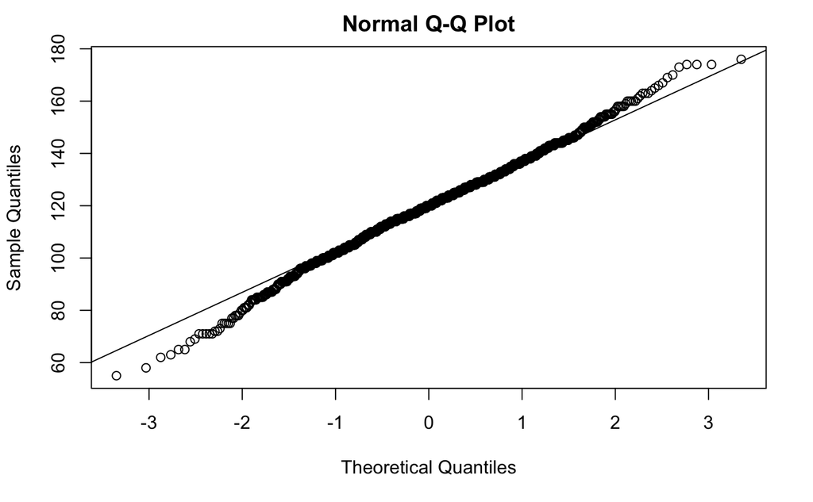

```r
qqnorm(data$bwt) # q-q plot against normal distribution
qqline(data$bwt)
```

For two sample comparison, if the plotted points are mostly above or below the $y=x$ line, then one can tell that the two samples most likely have a different mean.

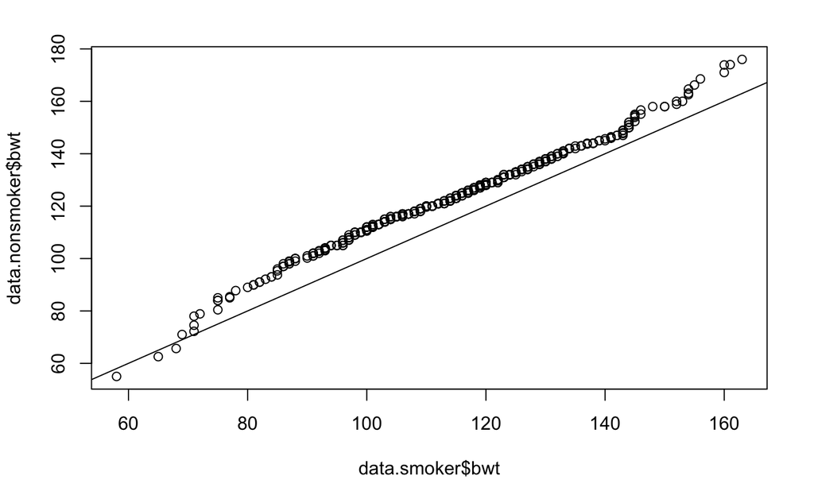

```r
qqplot(data.smoker$bwt, data.nonsmoker$bwt) # q-q plot of smoker and non-smoker samples
abline(c(0,1)) # reference line
```